# Homework 2

## Analysis of Relationship Between Gold Demand, Unemployement Rate and Interest Rate

### Pınar Köksal

In this homework, I compared quarter gold coin amount in Turkey with unemployement rate and term deposit account interest rates for 1-month period to see the relation between demand for gold and interest rates and unemployement rates in TÜİK webpage. The data is between 2020-01 and 2022-01, in monthly basis.

```r
# if packages do not exist, please install
#install.packages('openxlsx')
#install.packages('ggplot2')
#install.packages('data.table')
#install.packages('skimr')
#install.packages('GGally')
#install.packages('ggcorrplot')
#install.packages(file.choose(), repos=NULL)

options(warn=-1)

require(openxlsx) #library(openxlsx)
require(ggplot2)
require(data.table)
require(skimr)
require(GGally)
require(ggcorrplot)

data_path='C:/Users/pinar/Desktop/HW2_data.xlsx'
demand=read.xlsx(data_path,sheet='EVDS')
str(demand)
```

```
'data.frame':	25 obs. of  3 variables:
 $ Quarter.Coin.Amount  : num  602070 584380 889990 100040 581940 ...
 $ Unemployement.Rate   : num  14.1 13.5 13 12.8 12.6 13 14.6 13 12.4 12.8 ...
 $ Monthly.Interest.Rate: num  16.5 17 13.8 14 13 ...
```

```r
#Correlation analysis between the variables. This code worked on R but it didn't work here.

correl_info=cor(demand)

ggcorrplot(correl_info,
           hc.order = TRUE,
           type = "lower",
           lab = TRUE)
```

```
Error in ggcorrplot(correl_info, hc.order = TRUE, type = "lower", lab = TRUE): "ggcorrplot" fonksiyonu bulunamadı
Traceback:
```

The code above was supposed to demonstrate the correlation matrix but although it worked on R, it didn't run here. So I uploaded the image from R.

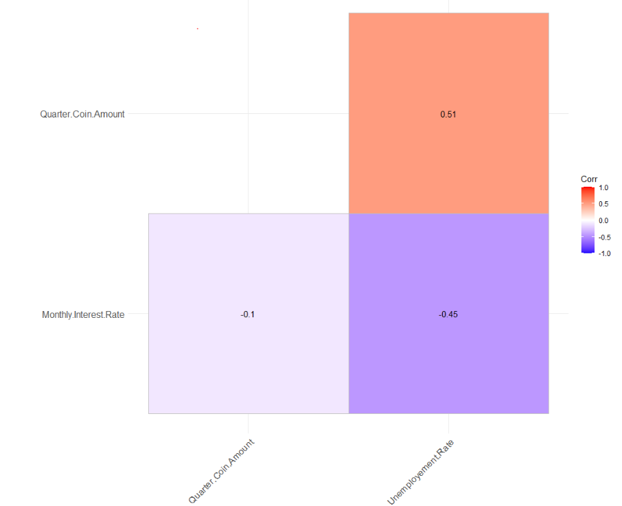

The results show that coin amount and unemployement rate has a correlation of 0.51. This is an unexpected result since we expect a decrease on the demand as the unemployement increase.

And there is a negative correlation of -0.1, between interest rate and coin amount.

```r
# #numerical statistics
summary_data=skim(demand)
print(summary_data)
```

```
-- Data Summary ------------------------
                           Values
Name                       demand
Number of rows             25
Number of columns          3
_______________________
Column type frequency:
  numeric                  3
________________________
Group variables            None

-- Variable type: numeric ------------------------------------------------------
  skim_variable         n_missing complete_rate     mean        sd   p0      p25
1 Quarter.Coin.Amount           0             1 826093.  903820.    0   206790
2 Unemployement.Rate            0             1     12.6      1.07 10.4     12.1
3 Monthly.Interest.Rate         0             1     18.3      4.04 13       14
       p50    p75      p100 hist
1 602070   889990 3318400   ▇▃▁▁▁
2     12.8     13      14.6 ▃▂▇▆▂
3     19.4     20      30   ▆▃▇▁▁
```

**$numeric** =

| skim_variable | n_missing | complete_rate | mean | sd | p0 | p25 | p50 | p75 | p100 | hist |
| --- | --- | --- | --- | --- | --- | --- | --- | --- | --- | --- |
| Quarter.Coin.Amount | 0 | 1 | 826093.0800 | 9.038198e+05 | 0.0 | 206790.0 | 602070.00 | 889990 | 3318400.0 | ▇▃▁▁▁ |
| Unemployement.Rate | 0 | 1 | 12.5680 | 1.066427e+00 | 10.4 | 12.1 | 12.80 | 13 | 14.6 | ▃▂▇▆▂ |
| Monthly.Interest.Rate | 0 | 1 | 18.3256 | 4.042921e+00 | 13.0 | 14.0 | 19.45 | 20 | 30.0 | ▆▃▇▁▁ |

Above is the statistical analysis of the data.

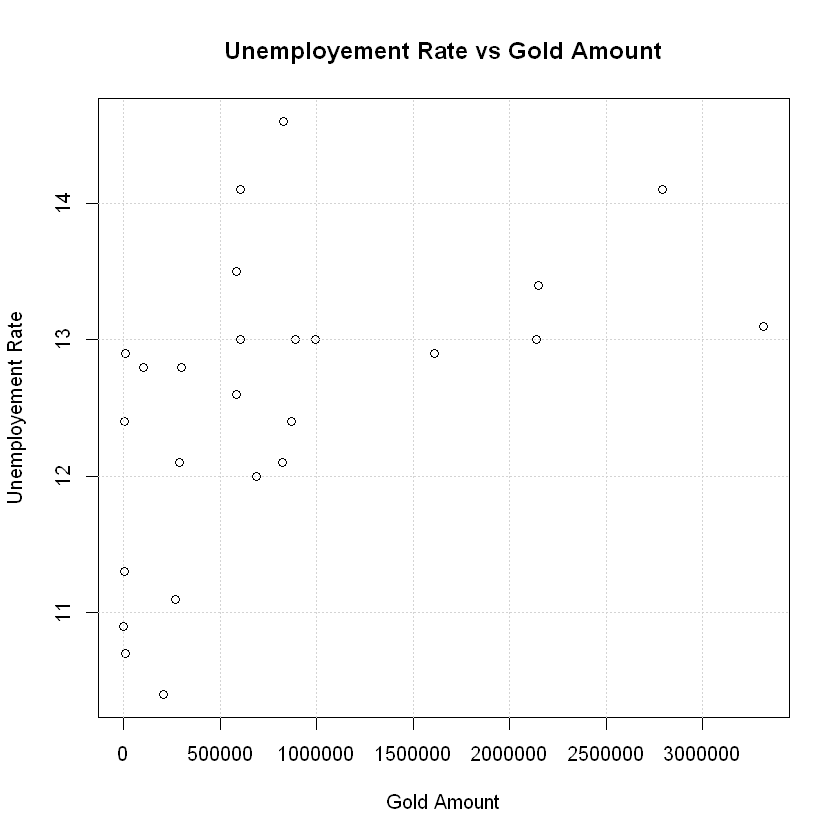

```r
#Plotting unemployement rate vs gold amount
plot(x = demand$Quarter.Coin.Amount, y= demand$Unemployement.Rate,
main="Unemployement Rate vs Gold Amount",ylab="Unemployement Rate",xlab="Gold Amount")
grid()
```

The graph above shows the unemployement rate and gold amount releation. There is variety and an increase in the gold amount as the unemployement rate increase as correlation coefficient indicated. Bu since it is not logical, it can be just a coincidence.

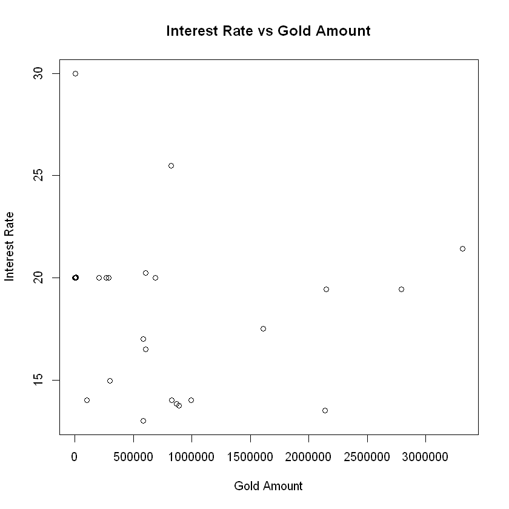

```r
#plotting interest rate vs gold amount
plot(x = demand$Quarter.Coin.Amount, y= demand$Monthly.Interest.Rate,
     main="Interest Rate vs Gold Amount",ylab="Interest Rate",xlab="Gold Amount")
```

And final graph shows interest rate vs gold amount. The data does not follow a specific pattern and it seems like there is not a strong correlation.

## Conclusion

Analysis show that there is a positive correlation between gold amount and unemployement rate. But I think both the unemployement and gold amount increase apart from each other due to the economic conditions in Turkey, and thus the results stated a positive correlation.

And expectedly, a negative correlation between intesest rate and gold amount is observed although it is not very strong.